# Apply függvénycsalád

Kurzus: Programozás I. 5. óra

Oktató: Balogh Kitti kttblgh@gmail.com

Időpont: 2017-03-14

## Vázlat

- Az `apply` függvénycsalád
- Az `apply` függvény
- A `lapply` függvény
- A `sapply` függvény
- A `mapply` függvény
- Hasonló függvény: az `aggregate`
- Összefoglalás
- Hatékonyabb package-ek
- Irodalom

## Az `apply` függvénycsalád

- Az `apply` függvénycsalád olyan függvényeket tartalmaz, amik kiválóan alkalmasak mátrixok, listák, vektorok és data frame-ek repetatív manipulálására, átalakítására.
- Kiváltják a ciklusok használatát és egy sokkal R-esebb módját nyújtják az iterációknak. Tulajdonképpen a ciklusok vektorizált megfelelői, amikkel hatékonyabban, pár sornyi kóddal tudunk műveleteket végrehajtani.
- Az egyes függvények más-más adatstruktúrájú inputon (mátrix, lista stb.) dolgoznak, és egy általunk megadott függvényt hajtanak végre az input egy vagy több elemén, során vagy oszlopán.
- Az output adatstruktúrája is eltérő lehet attól függően, hogy melyik függvényt használjuk.
- Az `apply` függvényeken belül meghívott függvény lehet egy package-ben definiált és a felhasználó által definiált függvény is. Pl.:
  - aggregáló függvény, mint a `mean` vagy a `sum`, ami egy értékkel fog visszatérni
  - más átalakító függvény, mint az `strsplit` vagy
  - bármilyen más vektorizált függvény.
- A függvénycsalád tagjai az `apply`, a `lapply`, a `sapply`, a `mapply`, a `vapply`, a `rapply` és a `tapply` függvények.

## Az `apply` függvény

- Az `apply` array objektumokon működik, mi mátrixokat fogunk nézni (2D array).
- A függvényt a következőképp hívjuk meg: `apply(X, MARGIN, FUN, ...)`, ahol:
  - `X` a mátrix. (Lehet data frame is, de mátrixszá fogja alakítani, úgyhogy nincs sok értelme.)
  - a `MARGIN` határozza meg, hogy a mátrix sorain (`MARGIN = 1`) vagy oszlopain (`MARGIN = 2`) hajtsa végre a műveletet. `MARGIN = c(1, 2)` esetén mindkét irányban végrehajtja.
  - a `FUN` argumentumnál a függvényt adjuk meg, amit alkalmazni szeretnénk a sorokon vagy az oszlopokon.

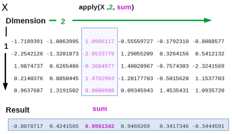

```r
#----apply függvény-------------------------------------------------------------
# 5x6-os mátrix st. normális elo-ból vett értékekkel
m <- matrix(rnorm(30), nrow = 5, ncol = 6)
m
```

```
##             [,1]       [,2]        [,3]        [,4]        [,5]       [,6]
## [1,]  1.11930000  0.3924724 -0.05417647  0.92561303  1.09807719  1.3049386
## [2,] -1.28797694  0.6325434  1.15273440 -0.35260525  0.73386050  0.6859790
## [3,]  0.05004057 -0.7709060 -0.03359018 -0.65382019 -0.68254798 -0.6166909
## [4,] -1.00566554 -0.1723259  1.41575345 -0.55835958 -0.06388658 -2.0626098
## [5,]  0.32036175  0.7976080 -0.24283895 -0.09515268 -0.38644086 -1.4989152
```

```r
# értékek összegének lekérése minden oszlopra
apply(m, 2, sum)
```

```
## [1] -0.8039402  0.8793919  2.2378823 -0.7343247  0.6990623 -2.1872983
```

```r
# értékek összegének lekérése minden sorra
apply(m, 1, sum)
```

```
## [1]  4.786225  1.564535 -2.707515 -2.447094 -1.105378
```

```r
# értékek átlagának lekérése minden sorra
apply(m, 1, mean)
```

```
## [1]  0.7977041  0.2607558 -0.4512524 -0.4078490 -0.1842297
```

## A `lapply` függvény

- A `lapply` függvényt is hasonlóan hívjuk meg: `lapply(X, FUN, ...)`, de itt nem értelmezhető az oszlop vagy a sor, mivel listákon dolgozik.
- Lista az input, aminek az elemei lehetnek szintén listák, data frame-ek, vektorok, stb.
- Olyan hosszúságú listával tér vissza, ahány eleme volt az input objektumnak.

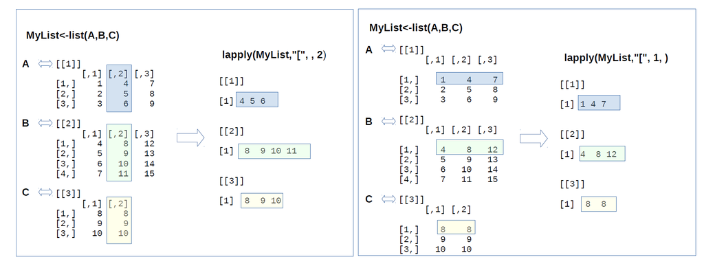

```r
#----lapply függvény------------------------------------------------------------
# 3 mátrix definiálása, majd összefűzése egy listába
A <- matrix(1:9, 3, 3)
B <- matrix(4:15, 4, 3)
C <- matrix(8:10, 3, 2)
MyList <- list(A, B, C)

# minden második oszlop kiszedése a mátrixok listájából
lapply(MyList, "[", , 2)
```

```
## [[1]]
## [1] 4 5 6
##
## [[2]]
## [1]  8  9 10 11
##
## [[3]]
## [1]  8  9 10
```

```r
# vagy
lapply(MyList, function(x) x[, 2])
```

```
## [[1]]
## [1] 4 5 6
##
## [[2]]
## [1]  8  9 10 11
##
## [[3]]
## [1]  8  9 10
```

```r
# minden első sor kiszedése a mátrixok listájából
lapply(MyList, "[", 1, )
```

```
## [[1]]
## [1] 1 4 7
##
## [[2]]
## [1]  4  8 12
##
## [[3]]
## [1] 8 8
```

```r
# vagy
lapply(MyList, function(x) x[1, ])
```

```
## [[1]]
## [1] 1 4 7
##
## [[2]]
## [1]  4  8 12
##
## [[3]]
## [1] 8 8
```

```r
# minden első sor 3. elem kiszedése a mátrixok listájából
lapply(MyList, "[", 1, 2)
```

```
## [[1]]
## [1] 4
##
## [[2]]
## [1] 8
##
## [[3]]
## [1] 8
```

```r
# vagy
lapply(MyList, function(x) x[1, 2])
```

```
## [[1]]
## [1] 4
##
## [[2]]
## [1] 8
##
## [[3]]
## [1] 8
```

```r
# mátrixok minden elemének összege
lapply(MyList, sum)
```

```
## [[1]]
## [1] 45
##
## [[2]]
## [1] 114
##
## [[3]]
## [1] 54
```

```r
# mátrixok első sorainak összege
lapply(MyList, function(x) sum(x[1, ]))
```

```
## [[1]]
## [1] 12
##
## [[2]]
## [1] 24
##
## [[3]]
## [1] 16
```

- A `lapply` első argumentuma az input objektum.
- A `[` jel a a kiválasztó operátor, ezután megszabjuk, hogy a sorokból és az oszlopokból melyik eleme(ke)t szeretnénk megkapni. Ahol üresen marad, az azt jelenti, hogy minden elemet meg szeretnénk kapni adott indexre.
- Vagy magunk definiálunk egy függvényt, amiben a megszokott módon indexelünk.

## A `sapply` függvény

- A `sapply` függvény is hasonlóan néz ki: `sapply(X, FUN, ..., simplify = TRUE)`
- Úgy működik, mint a `lapply`, de ha teheti, a lehető legegyszerűbb adatstruktúrával tér vissza, vektorral vagy mátrixszal. Ezt jelzi a `simplify = TRUE` argumentum. Ha ez `FALSE`, ugyanúgy működik, mint a `lapply`.

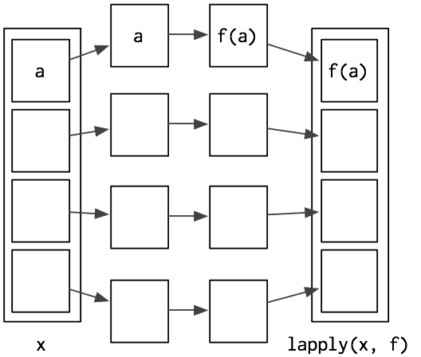

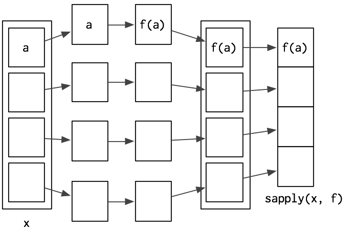

```r
#----sapply függvény------------------------------------------------------------
# minden második oszlop kiszedése a mátrixok listájából
sapply(MyList, function(x) x[, 2])
```

```
## [[1]]
## [1] 4 5 6
##
## [[2]]
## [1]  8  9 10 11
##
## [[3]]
## [1]  8  9 10
```

```r
# minden első sor 3. elem kiszedése a mátrixok listájából
sapply(MyList, "[", 1, 2)
```

```
## [1] 4 8 8
```

```r
# vagy
sapply(MyList, function(x) x[1, 2])
```

```
## [1] 4 8 8
```

```r
# mátrixok minden elemének összege
sapply(MyList, sum)
```

```
## [1]  45 114  54
```

```r
# mátrixok első sorainak összege
sapply(MyList, function(x) sum(x[1, ]))
```

```
## [1] 12 24 16
```

## A `mapply` függvény

- A `mapply` függvényt is hasonlóan hívjuk meg: `mapply(FUN, ..., simplify = TRUE)`, de itt nem értelmezhető az `X` argumentum, mert kimondottan egy függvényt szeretnénk repetatívan végrehajtani.
- A `mapply`-ra a `sapply` többváltozós verziójaként tekinthetünk.
- Az a célja, hogy olyan függvényekben is vektorizáltan tudjuk kezelni az argumentumokat, amik eredetileg nem fogadnak el vektorokat.

```r
#----mapply függvény------------------------------------------------------------
# 4x4-es mátrix, amit a rep függvény többszörös használátával hozunk létre
# a rep függvénnyel létrejövő vektorokat a c függvénnyel kapcsoljuk össze
m2 <- matrix(c(rep(1, 4), rep(2, 4), rep(3, 4), rep(4, 4)), 4, 4)
m2
```

```
##      [,1] [,2] [,3] [,4]
## [1,]    1    2    3    4
## [2,]    1    2    3    4
## [3,]    1    2    3    4
## [4,]    1    2    3    4
```

```r
# mapply segítségével
m2 <- mapply(rep, 1:4, 4)
m2
```

```
##      [,1] [,2] [,3] [,4]
## [1,]    1    2    3    4
## [2,]    1    2    3    4
## [3,]    1    2    3    4
## [4,]    1    2    3    4
```

## Hasonló függvény: az `aggregate`

- A használata: `aggregate(x, by, FUN, ..., simplify = TRUE)`
- Data frame-ek manipulálására jól alkalmazható.
- Abban hasonlít az `apply` függvénycsaládba tartozó függvényekhez, hogy az első argumentuma az az objektum, amin a függvényt végre szeretnénk hajtani. Ezt a függvény a `FUN` argumentummal tudjuk definiálni. A `sapply`-hoz hasonlóan a lehető legegyszerűbb adatstruktúrával tér vissza, amit a `simplify` argumentummal tudunk állítani.
- A különbség, hogy van egy `by` argumentuma, amivel meg tudjuk szabni, hogy milyen változókon vagy egy data frame mely részein szeretnénk alkalmazni a függvényt.
- Data frame-mel tér vissza.

## Összefoglalás

|  | Array | Dataframe | List | Vector |
| --- | --- | --- | --- | --- |
| Array | apply |  |  |  |
| Data frame |  | aggregate | by |  |
| List | sapply |  | lapply | sapply |
| Function arguments | mapply |  | mapply |  |

## Hatékonyabb package-ek

- Az `apply` függvénycsaládba tartozó függvények a `base` package tagjai.
- [`dplyr`](https://www.slideshare.net/shakthydoss/5-r-tutorial-dplyr-apply-function) - könnyen érthető nyelvezet
- [`data.table`](https://github.com/Rdatatable/data.table/wiki/Getting-started) - jobban skálázódik, gyors sok adatnál is
- [összehasonlítás](http://www.brodieg.com/?p=7)

## Irodalom

- Lander 11
- [DataCamp tutorial](https://www.datacamp.com/community/tutorials/r-tutorial-apply-family#family)
- [Advanced R](http://adv-r.had.co.nz/Functionals.html)